# Clinical Data for Obese vs Non-Obese

Quynh Tran and Dave Bridges

October 21, 2015

This file was last compiled on `Thu Aug 17 09:11:01 2017`. Unless otherwise noted this analysis removes subject 29.

# Analysis

Subjects in each group

| diagnosis | BMI.cat | n |
| --- | --- | --- |
| Control | Not Obese | 5 |
| Control | Obese | 6 |
| Cushing’s | Not Obese | 3 |
| Cushing’s | Obese | 5 |

## BMI

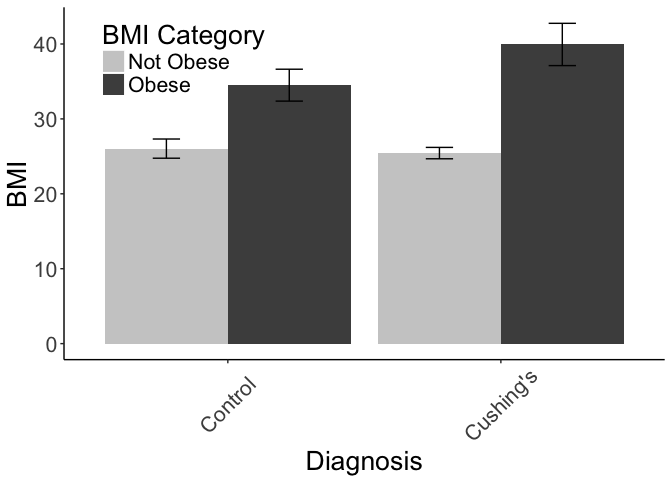

```r
library(ggplot2)
item <- 'BMI'
  #pdf(sprintf('../figures/Cushing-%s-barplot.pdf', gene))
  clinical.data <- all.o1[all.o1$measurement==item,]
  ggplot(clinical.data, aes(x=diagnosis, y=mean, fill=BMI.cat)) +
    geom_bar(position=position_dodge(), stat="identity") +
    geom_errorbar(aes(ymin=mean-se, ymax=mean+se),
                  width=.2,                    # Width of the error bars
                  position=position_dodge(.9)) +
    ylab("BMI") + xlab("Diagnosis") + guides(fill=guide_legend(title="BMI Category")) +
    theme(panel.grid.minor = element_blank()) +
    theme(panel.grid.major = element_blank()) +
    theme(panel.border=element_blank())+
    theme(axis.line = element_line(color = 'black')) +
    scale_fill_grey(start = 0.8, end = .3) +
    #guides(fill = guide_legend(keywidth = .5, keyheight = .5)) +
    theme(text = element_text(size=20), axis.text.x = element_text(angle=45,hjust=.5,vjust=.5)) +
    theme(legend.position=c(.20,.85))+
    theme(legend.background = element_rect(fill = "transparent", colour = "transparent")) +
    theme(panel.background = element_blank())
```

### BMI Statistics

Did a 2-way ANOVA on the BMI data

```r
bmi.aov <- aov(value~diagnosis*BMI.cat, data=subset(melted.data.used, measurement=="BMI"))
kable(summary(bmi.aov)[[1]], caption="2 Way ANOVA with interaction for BMI")
```

2 Way ANOVA with interaction for BMI

|  | Df | Sum Sq | Mean Sq | F value | Pr(>F) |
| --- | --- | --- | --- | --- | --- |
| diagnosis | 1 | 68.506 | 68.506 | 3.0991 | 0.09870 |
| BMI.cat | 1 | 549.548 | 549.548 | 24.8609 | 0.00016 |
| diagnosis:BMI.cat | 1 | 40.430 | 40.430 | 1.8290 | 0.19628 |
| Residuals | 15 | 331.574 | 22.105 | NA | NA |

# Glucose Homeostasis

```r
for (item in glucose.data.vars) {
  #pdf(sprintf('../figures/Cushing-%s-barplot.pdf', gene))
  clinical.data <- all.o1[all.o1$measurement==item,]
  ggplot(clinical.data, aes(x=diagnosis, y=mean, fill=BMI.cat)) +
    geom_bar(position=position_dodge(), stat="identity") +
    geom_errorbar(aes(ymin=mean-se, ymax=mean+se),
                  width=.2,                    # Width of the error bars
                  position=position_dodge(.9))+
    ggtitle(as.name(item))
  #ggsave(filename=paste('../Figures/Cushing_clinical_BMI/Cushing-BMI-', item, '-barplot.pdf',sep=""))
}
```

## HOMA Score

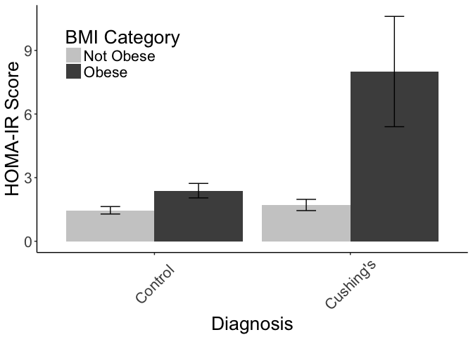

```r
item <- 'HOMA.IR'
  #pdf(sprintf('../figures/Cushing-%s-barplot.pdf', gene))
  clinical.data <- all.o1[all.o1$measurement==item,]
  ggplot(clinical.data, aes(x=diagnosis, y=mean, fill=BMI.cat)) +
    geom_bar(position=position_dodge(), stat="identity") +
    geom_errorbar(aes(ymin=mean-se, ymax=mean+se),
                  width=.2,                    # Width of the error bars
                  position=position_dodge(.9)) +
    ylab("HOMA-IR Score") + xlab("Diagnosis") + guides(fill=guide_legend(title="BMI Category")) +
    theme(panel.grid.minor = element_blank()) +
    theme(panel.grid.major = element_blank()) +
    theme(panel.border=element_blank())+
    theme(axis.line = element_line(color = 'black')) +
    scale_fill_grey(start = 0.8, end = .3) +
    #guides(fill = guide_legend(keywidth = .5, keyheight = .5)) +
    theme(text = element_text(size=20), axis.text.x = element_text(angle=45,hjust=.5,vjust=.5)) +
    theme(legend.position=c(.20,.80))+
    theme(legend.background = element_rect(fill = "transparent", colour = "transparent")) +
    theme(panel.background = element_blank())
```

Cushing’s disease resulted in a **3.35469** fold increase in HOMA-IR score in the obese subejcts but only a **1.17145** fold increase in the non-obese subjects.

### HOMA-IR Statistics

Did a 2-way ANOVA on the HOMA data

```r
homa.aov <- aov(value~diagnosis*BMI.cat, data=subset(melted.data.used, measurement=="HOMA.IR"))
kable(summary(homa.aov)[[1]], caption="2 Way ANOVA with interaction for HOMA-IR Score")
```

2 Way ANOVA with interaction for HOMA-IR Score

|  | Df | Sum Sq | Mean Sq | F value | Pr(>F) |
| --- | --- | --- | --- | --- | --- |
| diagnosis | 1 | 44.594 | 44.5939 | 6.7777 | 0.02186 |
| BMI.cat | 1 | 41.122 | 41.1223 | 6.2501 | 0.02659 |
| diagnosis:BMI.cat | 1 | 28.806 | 28.8059 | 4.3781 | 0.05659 |
| Residuals | 13 | 85.533 | 6.5795 | NA | NA |

There was a near-significant interaction between BMI and diagnosis for HOMA-IR score **(p=0.05659)**. The residuals of this model fail a Shapiro-Wilk test, so normality cannot be assumed (p=0.00195).

```r
for (item in clinical.data.vars) {
  #pdf(sprintf('../figures/Cushing-%s-barplot.pdf', gene))
  clinical.data <- all.o1[all.o1$measurement==item,]
  ggplot(clinical.data, aes(x=diagnosis, y=mean, fill=BMI.cat)) +
    geom_bar(position=position_dodge(), stat="identity") +
    geom_errorbar(aes(ymin=mean-se, ymax=mean+se),
                  width=.2,                    # Width of the error bars
                  position=position_dodge(.9))+
    ggtitle(as.name(item))
  #ggsave(filename=paste('../Figures/Cushing_clinical_BMI/Cushing-BMI-', item, '-barplot.pdf',sep=""))
}

for (item in lipid.data.vars) {
  #pdf(sprintf('../figures/Cushing-%s-barplot.pdf', gene))
  clinical.data <- all.o1[all.o1$measurement==item,]
  ggplot(clinical.data, aes(x=diagnosis, y=mean, fill=BMI.cat)) +
    geom_bar(position=position_dodge(), stat="identity") +
    geom_errorbar(aes(ymin=mean-se, ymax=mean+se),
                  width=.2,                    # Width of the error bars
                  position=position_dodge(.9))+
    ggtitle(as.name(item))
  #ggsave(filename=paste('../Figures/Cushing_clinical_BMI/Cushing-BMI-', item, '-barplot.pdf',sep=""))
}

for (item in lipolysis.data.vars) {
  #pdf(sprintf('../figures/Cushing-%s-barplot.pdf', gene))
  clinical.data <- all.o1[all.o1$measurement==item,]
  ggplot(clinical.data, aes(x=diagnosis, y=mean, fill=BMI.cat)) +
    geom_bar(position=position_dodge(), stat="identity") +
    geom_errorbar(aes(ymin=mean-se, ymax=mean+se),
                  width=.2,                    # Width of the error bars
                  position=position_dodge(.9))+
    ggtitle(as.name(item))
  #ggsave(filename=paste('../Figures/Cushing_clinical_BMI/Cushing-BMI-', item, '-barplot.pdf',sep=""))
}

for (item in liver.data.vars) {
  #pdf(sprintf('../figures/Cushing-%s-barplot.pdf', gene))
  clinical.data <- all.o1[all.o1$measurement==item,]
  ggplot(clinical.data, aes(x=diagnosis, y=mean, fill=BMI.cat)) +
    geom_bar(position=position_dodge(), stat="identity") +
    geom_errorbar(aes(ymin=mean-se, ymax=mean+se),
                  width=.2,                    # Width of the error bars
                  position=position_dodge(.9))+
    ggtitle(as.name(item))
  #ggsave(filename=paste('../Figures/Cushing_clinical_BMI/Cushing-BMI-', item, '-barplot.pdf',sep=""))
}
```

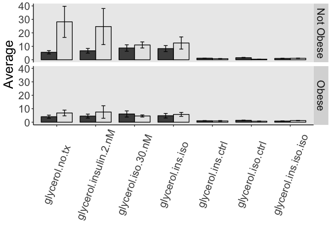

```r
####lipolysis graphs####
ggplot(lipolysis.stat, aes(x=measurement, y=mean, fill=diagnosis))+
    geom_bar(stat="identity",width=.8, position=position_dodge(width=.8), col="black", show_guide=F) +
    geom_errorbar(position=position_dodge(width=.8), aes(ymin=mean-se, ymax=mean+se), width=.2)+
    facet_grid(BMI.cat~.)+
    #theme_bw()+theme(axis.text.x=element_text(angle=90))+
    xlab("")+ ylab("Average") +
    theme(panel.grid.minor = element_blank()) + theme(panel.grid.major = element_blank()) +
    theme(panel.border=element_blank())+
    theme(axis.line = element_line(color = 'black')) +
    scale_fill_grey(start = 0.3, end = .9) +
    #guides(fill = guide_legend(keywidth = .5, keyheight = .5)) +
    theme(text = element_text(size=20), axis.text.x = element_text(angle=70,hjust=.5,vjust=.5)) +
    theme(legend.position=c(.60,.90))
```

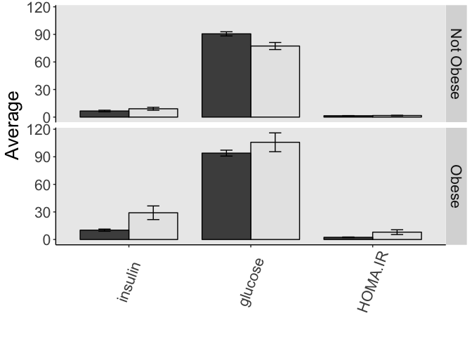

```r
#ggsave("../Figures/Cushing_clinical_BMI/Cushing-BMI-lipolysis-barplot.pdf")

####glucose graphs####
ggplot(glucose.stat, aes(x=measurement, y=mean, fill=diagnosis))+
    geom_bar(stat="identity",width=.8, position=position_dodge(width=.8), col="black", show_guide=F) +
    geom_errorbar(position=position_dodge(width=.8), aes(ymin=mean-se, ymax=mean+se), width=.2)+
    facet_grid(BMI.cat~.)+
    #theme_bw()+theme(axis.text.x=element_text(angle=90))+
    xlab("")+ ylab("Average") +
    theme(panel.grid.minor = element_blank()) + theme(panel.grid.major = element_blank()) +
    theme(panel.border=element_blank())+
    theme(axis.line = element_line(color = 'black')) +
    scale_fill_grey(start = 0.3, end = .9) +
    #guides(fill = guide_legend(keywidth = .5, keyheight = .5)) +
    theme(text = element_text(size=20), axis.text.x = element_text(angle=70,hjust=.5,vjust=.5)) +
    theme(legend.position=c(.60,.90))
```

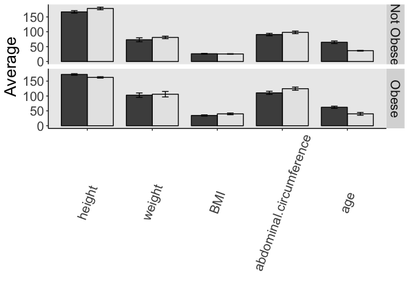

```r
#ggsave("../Figures/Cushing_clinical_BMI/Cushing-BMI-glucosePanel-barplot.pdf")


####clinical graphs####
ggplot(clinical.stat, aes(x=measurement, y=mean, fill=diagnosis))+
    geom_bar(stat="identity",width=.8, position=position_dodge(width=.8), col="black", show_guide=F) +
    geom_errorbar(position=position_dodge(width=.8), aes(ymin=mean-se, ymax=mean+se), width=.2)+
    facet_grid(BMI.cat~.)+
    #theme_bw()+
    theme(axis.text.x=element_text(angle=90))+
    xlab("")+ ylab("Average") +
    theme(panel.grid.minor = element_blank()) + theme(panel.grid.major = element_blank()) +
    theme(panel.border=element_blank())+
    theme(axis.line = element_line(color = 'black')) +
    scale_fill_grey(start = 0.3, end = .9) +
    guides(fill = guide_legend(keywidth = .5, keyheight = .5)) +
    theme(text = element_text(size=20), axis.text.x = element_text(angle=70,hjust=.5,vjust=.5)) +
    theme(legend.position=c(.60,.90))
```

```r
#ggsave("../Figures/Cushing_clinical_BMI/Cushing-BMI-clinicalPanel-barplot.pdf")
```

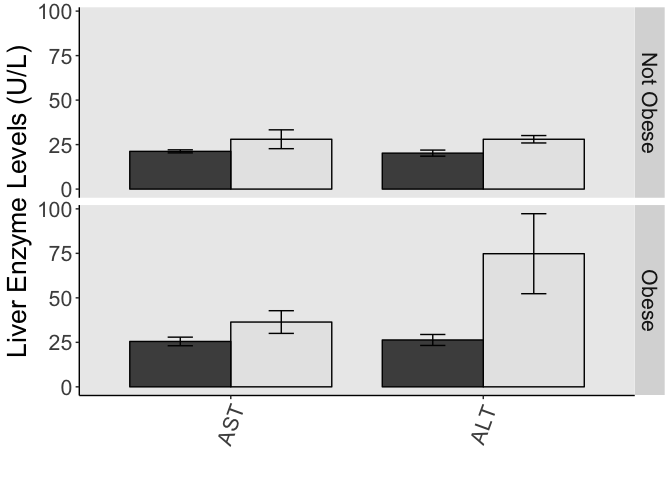

```r
####liver graphs####
ggplot(liver.stat, aes(x=measurement, y=mean, fill=diagnosis))+
    geom_bar(stat="identity",width=.8, position=position_dodge(width=.8), col="black", show_guide=F) +
    geom_errorbar(position=position_dodge(width=.8), aes(ymin=mean-se, ymax=mean+se), width=.2)+
    facet_grid(BMI.cat~.)+
    #theme_bw()+
    theme(axis.text.x=element_text(angle=90))+
    xlab("")+ ylab("Liver Enzyme Levels (U/L)") +
    theme(panel.grid.minor = element_blank()) + theme(panel.grid.major = element_blank()) +
    theme(panel.border=element_blank())+
    theme(axis.line = element_line(color = 'black')) +
    scale_fill_grey(start = 0.3, end = .9) +
    guides(fill = guide_legend(keywidth = .5, keyheight = .5)) +
    theme(text = element_text(size=20), axis.text.x = element_text(angle=70,hjust=.5,vjust=.5)) +
    theme(legend.position=c(.60,.90))
```

```r
#ggsave("../Figures/Cushing_clinical_BMI/Cushing-BMI-liverPanel-barplot.pdf")
```

## Liver Enzymes

### AST

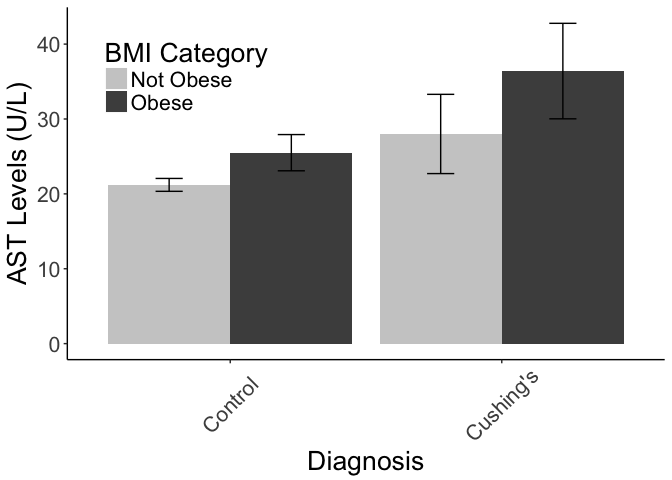

```r
item <- 'AST'
  #pdf(sprintf('../figures/Cushing-%s-barplot.pdf', gene))
  clinical.data <- all.o1[all.o1$measurement==item,]
  ggplot(clinical.data, aes(x=diagnosis, y=mean, fill=BMI.cat)) +
    geom_bar(position=position_dodge(), stat="identity") +
    geom_errorbar(aes(ymin=mean-se, ymax=mean+se),
                  width=.2,                    # Width of the error bars
                  position=position_dodge(.9)) +
    ylab("AST Levels (U/L)") + xlab("Diagnosis") + guides(fill=guide_legend(title="BMI Category")) +
    theme(panel.grid.minor = element_blank()) +
    theme(panel.grid.major = element_blank()) +
    theme(panel.border=element_blank())+
    theme(axis.line = element_line(color = 'black')) +
    scale_fill_grey(start = 0.8, end = .3) +
    #guides(fill = guide_legend(keywidth = .5, keyheight = .5)) +
    theme(text = element_text(size=20), axis.text.x = element_text(angle=45,hjust=.5,vjust=.5)) +
    theme(legend.position=c(.20,.80))+
    theme(legend.background = element_rect(fill = "transparent", colour = "transparent")) +
    theme(panel.background = element_blank())
```

#### AST Statistics

Did a 2-way ANOVA on the AST data

```r
ast.aov <- aov(value~diagnosis*BMI.cat, data=subset(melted.data.used, measurement=="AST"))
kable(summary(ast.aov)[[1]], caption="2 Way ANOVA with interaction for AST Levels")
```

2 Way ANOVA with interaction for AST Levels

|  | Df | Sum Sq | Mean Sq | F value | Pr(>F) |
| --- | --- | --- | --- | --- | --- |
| diagnosis | 1 | 436.194 | 436.194 | 5.58507 | 0.03204 |
| BMI.cat | 1 | 164.049 | 164.049 | 2.10051 | 0.16783 |
| diagnosis:BMI.cat | 1 | 18.678 | 18.678 | 0.23915 | 0.63189 |
| Residuals | 15 | 1171.500 | 78.100 | NA | NA |

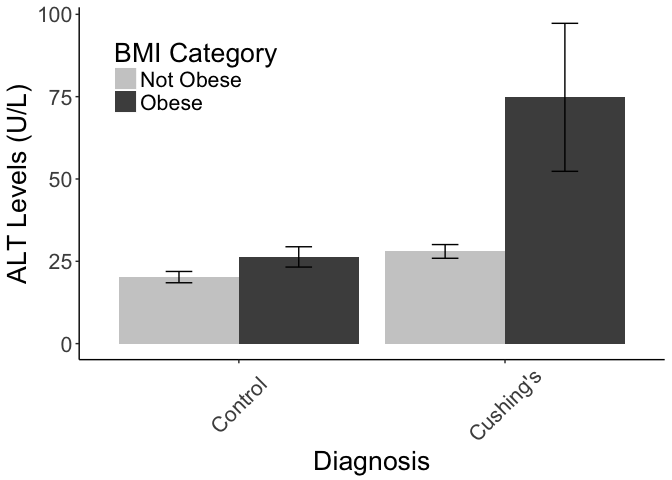

```r
item <- 'ALT'
  #pdf(sprintf('../figures/Cushing-%s-barplot.pdf', gene))
  clinical.data <- all.o1[all.o1$measurement==item,]
  ggplot(clinical.data, aes(x=diagnosis, y=mean, fill=BMI.cat)) +
    geom_bar(position=position_dodge(), stat="identity") +
    geom_errorbar(aes(ymin=mean-se, ymax=mean+se),
                  width=.2,                    # Width of the error bars
                  position=position_dodge(.9)) +
    ylab("ALT Levels (U/L)") + xlab("Diagnosis") + guides(fill=guide_legend(title="BMI Category")) +
    theme(panel.grid.minor = element_blank()) +
    theme(panel.grid.major = element_blank()) +
    theme(panel.border=element_blank())+
    theme(axis.line = element_line(color = 'black')) +
    scale_fill_grey(start = 0.8, end = .3) +
    #guides(fill = guide_legend(keywidth = .5, keyheight = .5)) +
    theme(text = element_text(size=20), axis.text.x = element_text(angle=45,hjust=.5,vjust=.5)) +
    theme(legend.position=c(.20,.80))+
    theme(legend.background = element_rect(fill = "transparent", colour = "transparent")) +
    theme(panel.background = element_blank())
```

Cushing’s disease resulted in a **2.84051** fold increase in ALT levels in the obese subejcts but only a **1.38614** fold increase in the non-obese subjects.

#### ALT Statistics

Did a 2-way ANOVA on the ALT data

```r
alt.aov <- aov(value~diagnosis*BMI.cat, data=subset(melted.data.used, measurement=="ALT"))
kable(summary(alt.aov)[[1]], caption="2 Way ANOVA with interaction for ALT Levels")
```

2 Way ANOVA with interaction for ALT Levels

|  | Df | Sum Sq | Mean Sq | F value | Pr(>F) |
| --- | --- | --- | --- | --- | --- |
| diagnosis | 1 | 5261.5 | 5261.46 | 7.5387 | 0.01502 |
| BMI.cat | 1 | 2371.8 | 2371.76 | 3.3983 | 0.08511 |
| diagnosis:BMI.cat | 1 | 1837.5 | 1837.53 | 2.6328 | 0.12550 |
| Residuals | 15 | 10468.9 | 697.93 | NA | NA |